# Materi-1

# Gabung Data

```r
library(readxl)
library(writexl)
tahun <- c(2010:2021)
file_list <- paste0(tahun, ".xlsx")

data_gabung <- data.frame()

for (i in seq_along(file_list)) {
  # Baca file tanpa skip karena baris ACEH sudah berada di baris ke-4
  temp_data <- read_excel(file_list[i], col_names = FALSE)

  # Ambil kolom 1 (Provinsi) dan kolom 2 (IPM)
  temp_data <- temp_data[, 1:2]
  colnames(temp_data) <- c("Provinsi", "IPM")

  # Cari posisi baris "ACEH" secara presisi agar data di atasnya (judul) terbuang bersih
  idx_aceh <- which(trimws(toupper(temp_data$Provinsi)) == "ACEH")

  if (length(idx_aceh) > 0) {
    # Ambil data mulai dari baris ACEH ke bawah
    start_row <- idx_aceh[1]
    temp_data <- temp_data[start_row:nrow(temp_data), ]

    # Hapus baris yang nilai provinsinya NA atau kosong
    temp_data <- temp_data[!is.na(temp_data$Provinsi) & temp_data$Provinsi != "", ]

    # Tambahkan kolom Tahun
    temp_data$Tahun <- tahun[i]

    # Gabungkan ke dataframe utama
    if (i == 1) {
      data_gabung <- temp_data
    } else {
      data_gabung <- rbind(data_gabung, temp_data)
    }
  }
}
# Membersihkan Data (Menangani tanda strip "-" atau sel kosong)
data_gabung$IPM[data_gabung$IPM == "-" | data_gabung$IPM == "" | data_gabung$IPM == " "] <- NA

# Mengubah tipe data kolom IPM dari karakter menjadi angka (numeric)
data_gabung$IPM <- as.numeric(data_gabung$IPM)

# Cek 10 baris pertama untuk memastikan ACEH sudah ada di paling atas
head(data_gabung, 10)
```

```
## # A tibble: 10 × 3
##    Provinsi               IPM Tahun
##    <chr>                <dbl> <int>
##  1 ACEH                  67.1  2010
##  2 SUMATERA UTARA        67.1  2010
##  3 SUMATERA BARAT        67.2  2010
##  4 RIAU                  68.6  2010
##  5 JAMBI                 65.4  2010
##  6 SUMATERA SELATAN      64.4  2010
##  7 BENGKULU              65.4  2010
##  8 LAMPUNG               63.7  2010
##  9 KEP. BANGKA BELITUNG  66.0  2010
## 10 KEP. RIAU             71.1  2010
```

```r
# Simpan hasil akhir yang sudah bersih
write_xlsx(data_gabung, "Data_Tugas_Kuliah_K2.xlsx")
```

# Package

```r
library(readxl)
library(lmtest)
library(orcutt)
```

# Import Data

```r
data <- read_excel("Data_Tugas_Kuliah_K2.xlsx")

head(data)
```

```
## # A tibble: 6 × 3
##   Provinsi           IPM Tahun
##   <chr>            <dbl> <dbl>
## 1 ACEH              67.1  2010
## 2 SUMATERA UTARA    67.1  2010
## 3 SUMATERA BARAT    67.2  2010
## 4 RIAU              68.6  2010
## 5 JAMBI             65.4  2010
## 6 SUMATERA SELATAN  64.4  2010
```

# Pilih Satu Provinsi (Kep. Riau)

```r
data_kr <- subset(data, Provinsi == "KEP. RIAU")

data_kr
```

```
## # A tibble: 12 × 3
##    Provinsi    IPM Tahun
##    <chr>     <dbl> <dbl>
##  1 KEP. RIAU  71.1  2010
##  2 KEP. RIAU  71.6  2011
##  3 KEP. RIAU  72.4  2012
##  4 KEP. RIAU  73.0  2013
##  5 KEP. RIAU  73.4  2014
##  6 KEP. RIAU  73.8  2015
##  7 KEP. RIAU  74.0  2016
##  8 KEP. RIAU  74.4  2017
##  9 KEP. RIAU  74.8  2018
## 10 KEP. RIAU  75.5  2019
## 11 KEP. RIAU  75.6  2020
## 12 KEP. RIAU  75.8  2021
```

```r
data_kr <- data_kr[order(data_kr$Tahun), ]

data_kr
```

```
## # A tibble: 12 × 3
##    Provinsi    IPM Tahun
##    <chr>     <dbl> <dbl>
##  1 KEP. RIAU  71.1  2010
##  2 KEP. RIAU  71.6  2011
##  3 KEP. RIAU  72.4  2012
##  4 KEP. RIAU  73.0  2013
##  5 KEP. RIAU  73.4  2014
##  6 KEP. RIAU  73.8  2015
##  7 KEP. RIAU  74.0  2016
##  8 KEP. RIAU  74.4  2017
##  9 KEP. RIAU  74.8  2018
## 10 KEP. RIAU  75.5  2019
## 11 KEP. RIAU  75.6  2020
## 12 KEP. RIAU  75.8  2021
```

Analisis difokuskan pada **Provinsi Kepulauan Riau (KEP. RIAU)**. Data yang digunakan merupakan pengamatan IPM berdasarkan tahun yang tersedia pada dataset.

# 1. Pemodelan Regresi

## a. Model Regresi

```r
model <- lm(IPM ~ Tahun, data = data_kr)

summary(model)
```

```
##
## Call:
## lm(formula = IPM ~ Tahun, data = data_kr)
##
## Residuals:
##      Min       1Q   Median       3Q      Max
## -0.32897 -0.14432  0.01181  0.18608  0.29711
##
## Coefficients:
##               Estimate Std. Error t value Pr(>|t|)
## (Intercept) -781.81672   38.55893  -20.28 1.88e-09 ***
## Tahun          0.42451    0.01913   22.19 7.76e-10 ***
## ---
## Signif. codes:  0 '***' 0.001 '**' 0.01 '*' 0.05 '.' 0.1 ' ' 1
##
## Residual standard error: 0.2288 on 10 degrees of freedom
## Multiple R-squared:  0.9801, Adjusted R-squared:  0.9781
## F-statistic: 492.4 on 1 and 10 DF,  p-value: 7.755e-10
```

Model regresi linear digunakan untuk mengetahui hubungan antara **Tahun** sebagai variabel bebas dan **IPM** sebagai variabel respon.

Berdasarkan hasil estimasi, diperoleh persamaan regresi:

$$\hat{IPM} = -781.8167 + 0.4245
(Tahun)$$

Koefisien Tahun bernilai **positif sebesar 0.4245**, sehingga setiap peningkatan satu tahun diperkirakan meningkatkan IPM sebesar **0.4245 poin**, dengan asumsi hubungan linear.

## b. Plot Data dan Regresi

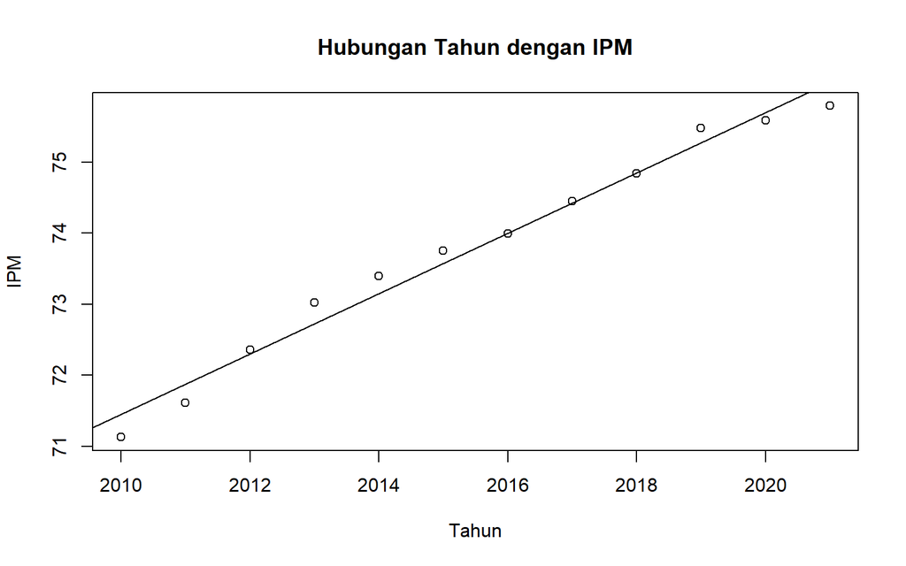

```r
plot(data_kr$Tahun, data_kr$IPM,
     xlab = "Tahun",
     ylab = "IPM",
     main = "Hubungan Tahun dengan IPM")

abline(model)
```

Plot menunjukkan adanya **pola hubungan positif** antara tahun dan IPM. Garis regresi memiliki arah meningkat, yang menunjukkan bahwa secara umum nilai IPM KEP. RIAU cenderung meningkat seiring bertambahnya tahun.

# 2. Cek Autokorelasi

## a. Plot Sisaan

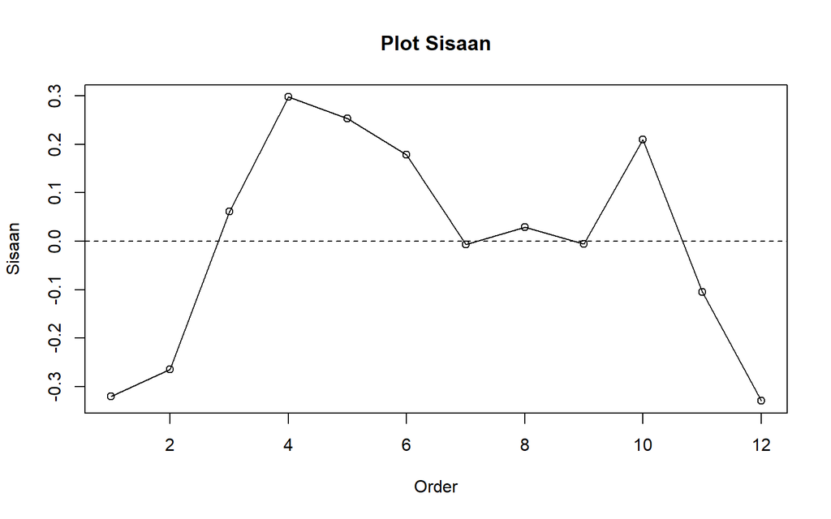

```r
plot(residuals(model),
     type = "o",
     xlab = "Order",
     ylab = "Sisaan",
     main = "Plot Sisaan")
abline(h = 0, lty = 2)
```

Plot sisaan digunakan untuk melihat pola sisaan berdasarkan urutan waktu. Terlihat adanya pola pada sisaan antarperiode, sehingga terdapat indikasi bahwa sisaan pada suatu periode masih berkaitan dengan sisaan pada periode sebelumnya. Hal ini mengindikasikan adanya kemungkinan autokorelasi pada sisaan.

Pada data ini terlihat pola pada sisaan, sehingga pemeriksaan autokorelasi perlu dilanjutkan menggunakan ACF dan uji Durbin-Watson.

## b. ACF Sisaan

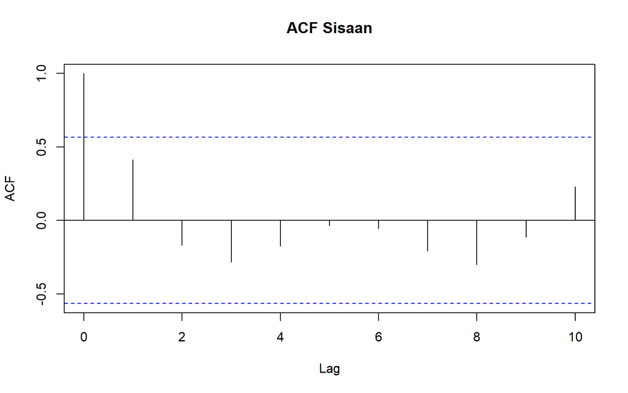

```r
acf(residuals(model),
    main = "ACF Sisaan")
```

ACF digunakan untuk melihat korelasi antara sisaan pada suatu waktu dengan sisaan pada waktu sebelumnya.

## c. Uji Durbin Watson

```r
library(lmtest)

dwtest(model)
```

```
##
##  Durbin-Watson test
##
## data:  model
## DW = 0.7724, p-value = 0.001426
## alternative hypothesis: true autocorrelation is greater than 0
```

Hipotesis yang digunakan adalah:

$$H_0 : \rho = 0$$

$$H_1 : \rho > 0$$

Hasil uji Durbin-Watson menunjukkan nilai statistik **DW = 0.7724** dengan **p-value = 0.001426**.

Karena p-value **0.001426 < 0.05**, maka $H_0$ **ditolak**. Dengan demikian, terdapat **autokorelasi positif pada sisaan model regresi**.

Nilai DW yang cukup jauh di bawah 2 juga mendukung adanya autokorelasi positif.

# 3. Cochrane-Orcutt

## a. Model Cochrane-Orcutt

```r
cochrane.model <- cochrane.orcutt(model)

cochrane.model
```

```
## Cochrane-orcutt estimation for first order autocorrelation
##
## Call:
## lm(formula = IPM ~ Tahun, data = data_kr)
##
##  number of interaction: 76
##  rho 0.651462
##
## Durbin-Watson statistic
## (original):    0.77240 , p-value: 1.426e-03
## (transformed): 1.94827 , p-value: 3.15e-01
##
##  coefficients:
## (Intercept)       Tahun
## -613.259516    0.340992
```

Metode Cochrane-Orcutt digunakan untuk mengatasi masalah autokorelasi positif yang ditemukan pada model awal.

## b. Lihat Rho

```r
cochrane.model$rho
```

```
## [1] 0.6514619
```

Hasil estimasi menghasilkan nilai:

$$\hat{\rho} = 0.651462$$

Nilai $\rho$ yang positif menunjukkan adanya korelasi positif yang cukup kuat antara sisaan pada periode yang berurutan.

## c. Lihat Koefisien

```r
cochrane.model$coefficients
```

```
##  (Intercept)        Tahun
## -613.2595157    0.3409918
```

Persamaan regresi setelah penanganan Cochrane-Orcutt adalah:

$$\hat{IPM} = -613.2595157 +
0.3409918(Tahun)$$

Koefisien Tahun sebesar **0.3409918** menunjukkan bahwa setiap peningkatan satu tahun diperkirakan meningkatkan IPM sebesar **0.3409918 poin** setelah masalah autokorelasi ditangani.

## d. Lihat DW setelah Cochrane-Orcutt

```r
cochrane.model$DW
```

```
##          DW                      DW
## 0.772404555 0.001425624 1.948267218 0.315035688
```

Setelah dilakukan transformasi Cochrane-Orcutt, nilai DW meningkat dari **0.7724 menjadi 1.9483**. Nilai tersebut sudah mendekati 2, sehingga menunjukkan bahwa autokorelasi pada sisaan telah berkurang. Selain itu, p-value DW setelah transformasi sebesar **0.3150 > 0.05**, sehingga $H_0$ tidak ditolak. Dengan demikian, **tidak terdapat bukti yang cukup adanya autokorelasi positif setelah penanganan Cochrane-Orcutt**.

# 4. Hildreth-Lu

## a. Fungsi Hildreth-Lu

```r
hildreth.lu <- function (rho, model) {
  x <- model.matrix(model)[, -1]
  y <- model.response(model.frame(model))
  n <- length(y)
  t <- 2:n
  y <- y[t] - rho * y[t-1]
  x <- x[t] - rho * x[t-1]
  return(lm(y ~ x))
}
```

Fungsi `hildreth.lu()` dibuat untuk melakukan transformasi data berdasarkan nilai ρ tertentu. Metode Hildreth-Lu kemudian membandingkan beberapa nilai $\rho$ untuk menentukan nilai yang menghasilkan **SSE paling kecil**.

## b. Tentukan Kandidat Rho

```r
rho <- c(seq(0.1, 0.8, by = 0.1),
         seq(0.90, 0.99, by = 0.01))

rho
```

```
##  [1] 0.10 0.20 0.30 0.40 0.50 0.60 0.70 0.80 0.90 0.91 0.92 0.93 0.94 0.95 0.96
## [16] 0.97 0.98 0.99
```

Beberapa kandidat nilai $\rho$ ditentukan untuk mencari nilai parameter autokorelasi yang paling sesuai. Kandidat awal berada pada rentang **0.10–0.80**, kemudian dilanjutkan dengan nilai **0.90–0.99**.

## c. Hitung SSE

```r
tab <- data.frame(
  rho = rho,
  SSE = sapply(rho, function(r)
    deviance(hildreth.lu(r, model)))
)

tab
```

```
##     rho       SSE
## 1  0.10 0.3342456
## 2  0.20 0.2971473
## 3  0.30 0.2674471
## 4  0.40 0.2451449
## 5  0.50 0.2302407
## 6  0.60 0.2227345
## 7  0.70 0.2226264
## 8  0.80 0.2299162
## 9  0.90 0.2446041
## 10 0.91 0.2464798
## 11 0.92 0.2484294
## 12 0.93 0.2504531
## 13 0.94 0.2525507
## 14 0.95 0.2547223
## 15 0.96 0.2569679
## 16 0.97 0.2592874
## 17 0.98 0.2616810
## 18 0.99 0.2641485
```

Untuk setiap kandidat $\rho$ , dihitung nilai **Sum of Squared Errors (SSE)** setelah transformasi Hildreth-Lu.

Nilai $\rho$ yang dipilih adalah nilai yang menghasilkan **SSE paling kecil**, karena menunjukkan model hasil transformasi dengan kesalahan kuadrat terkecil.

## d. Cari Rho dengan SSE Minimum

```r
tab[tab$SSE == min(tab$SSE), ]
```

```
##   rho       SSE
## 7 0.7 0.2226264
```

Berdasarkan tabel SSE, nilai ρ dipilih berdasarkan **SSE minimum**. Dari hasil pencarian, nilai $\rho$ yang memberikan SSE minimum berada di sekitar **0.70**, sehingga pencarian kemudian diperhalus di sekitar rentang tersebut.

## e. Memperhalus Nilai Rho

```r
rho <- seq(0.70, 0.80, by = 0.01)

tab <- data.frame(
  rho = rho,
  SSE = sapply(rho, function(r)
    deviance(hildreth.lu(r, model)))
)

round(tab, 4)
```

```
##     rho    SSE
## 1  0.70 0.2226
## 2  0.71 0.2230
## 3  0.72 0.2235
## 4  0.73 0.2240
## 5  0.74 0.2247
## 6  0.75 0.2253
## 7  0.76 0.2261
## 8  0.77 0.2270
## 9  0.78 0.2279
## 10 0.79 0.2289
## 11 0.80 0.2299
```

```r
tab[tab$SSE == min(tab$SSE), ]
```

```
##   rho       SSE
## 1 0.7 0.2226264
```

Pencarian $\rho$ diperhalus pada rentang **0.70–0.80** dengan interval 0.01 untuk memperoleh nilai $\rho$ yang lebih presisi.

## f. Rho Optimum

```r
rho_opt <- tab$rho[which.min(tab$SSE)]

rho_opt
```

```
## [1] 0.7
```

Hasil pencarian menunjukkan bahwa $\rho = 0.7$ menghasilkan SSE minimum. Oleh karena itu, $\rho = 0.7$ **dipilih sebagai nilai rho optimum** untuk model Hildreth-Lu.

## g. Plot SSE vs Rho

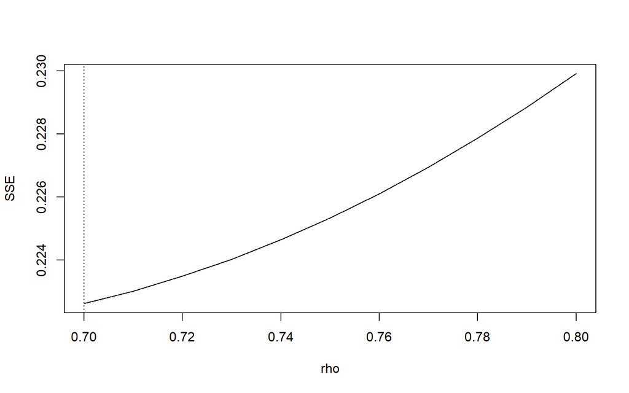

```r
plot(SSE ~ rho, tab, type = "l")

abline(
  v = tab[tab$SSE == min(tab$SSE), "rho"],
  lty = 3
)
```

Plot menunjukkan hubungan antara nilai $\rho$ dan SSE. Nilai $\rho$ optimum ditunjukkan oleh garis vertikal pada titik ketika **SSE mencapai nilai minimum**.

Pada data ini, titik minimum berada pada sekitar$\rho = 0.7$ , sehingga nilai tersebut digunakan dalam model Hildreth-Lu.

## h. Model Hildreth-Lu

```r
fit <- hildreth.lu(rho_opt, model)
summary(fit)
```

```
##
## Call:
## lm(formula = y ~ x)
##
## Residuals:
##      Min       1Q   Median       3Q      Max
## -0.19832 -0.12661 -0.02344  0.08688  0.29570
##
## Coefficients:
##               Estimate Std. Error t value Pr(>|t|)
## (Intercept) -174.02644   30.26663  -5.750 0.000276 ***
## x              0.32458    0.04999   6.493 0.000112 ***
## ---
## Signif. codes:  0 '***' 0.001 '**' 0.01 '*' 0.05 '.' 0.1 ' ' 1
##
## Residual standard error: 0.1573 on 9 degrees of freedom
## Multiple R-squared:  0.8241, Adjusted R-squared:  0.8045
## F-statistic: 42.16 on 1 and 9 DF,  p-value: 0.0001123
```

```r
dwtest(fit)
```

```
##
##  Durbin-Watson test
##
## data:  fit
## DW = 2.004, p-value = 0.3509
## alternative hypothesis: true autocorrelation is greater than 0
```

Berdasarkan metode Hildreth-Lu dengan nilai $\rho\ optimum$ sebesar 0.7, diperoleh model hasil transformasi dengan koefisien Tahun sebesar 0.32458 dan p-value sebesar 0.0001123, sehingga terdapat hubungan linear yang signifikan antara Tahun dan IPM.

## i. Uji DW setelah Hildreth-Lu

```r
dwtest(fit)
```

```
##
##  Durbin-Watson test
##
## data:  fit
## DW = 2.004, p-value = 0.3509
## alternative hypothesis: true autocorrelation is greater than 0
```

Setelah dilakukan penanganan autokorelasi menggunakan metode Hildreth-Lu, nilai DW meningkat menjadi sekitar **2.004** dengan p-value sebesar 0.3509. Karena p-value > 0.05, maka $H_0$ tidak ditolak.

Nilai tersebut sangat dekat dengan 2, sehingga menunjukkan bahwa **autokorelasi pada sisaan telah berhasil dikurangi**. Dengan demikian, model hasil transformasi Hildreth-Lu sudah jauh lebih memenuhi asumsi tidak adanya autokorelasi dibandingkan model awal.

## j. Persamaan Regresi setelah Hildreth-Lu/Transformasi Balik

```r
cat("IPM =", coef(fit)[2], "Tahun +",
    coef(fit)[1] / (1 - rho_opt), sep = "")
```

```
## IPM =0.3245758Tahun +-580.0881
```

Hasil transformasi kembali memberikan persamaan regresi pada skala awal:

$$\hat{IPM} = -580.0881 +
0.3245758(Tahun)$$

# 5. Kesimpulan

Berdasarkan hasil analisis regresi IPM terhadap Tahun pada Provinsi Kepulauan Riau, diperoleh indikasi adanya autokorelasi positif pada sisaan. Hal ini didukung oleh hasil uji Durbin-Watson yang menghasilkan nilai DW sebesar **0.77240** dengan p-value **0.001426**, sehingga $H_0$ ditolak dan terdapat autokorelasi positif pada sisaan. Penanganan autokorelasi dilakukan menggunakan metode Cochrane-Orcutt dan Hildreth-Lu. Cochrane-Orcutt menghasilkan estimasi $\rho$ sebesar **0.6514619** dan meningkatkan nilai DW menjadi **1.94827218**. Sementara itu, metode Hildreth-Lu menghasilkan nilai $\rho$ optimum sebesar **0.7** berdasarkan SSE minimum dan nilai DW sebesar **2.004**. Kedua metode menghasilkan nilai DW yang mendekati 2, sehingga dapat disimpulkan bahwa penanganan autokorelasi berhasil mengurangi masalah autokorelasi pada sisaan model.